# Hierarchical_Clustering

Nadia Kennar, UKDS , modified by Ben Anderson

2022-11-01

## Recap on hierachical clustering

Hierarchical clustering, also known as hierarchical cluster analysis, is an algorithm that clusters similar data points into groups called clusters. The endpoint is a hierarchy of clusters and the objects within each cluster are similar to each other.

There are two approaches:

- Agglomerative: This is a “bottom-up” approach: each observation starts in its own cluster, and pairs of clusters are merged as one moves up the hierarchy.
- Divisive: This is a “top-down” approach: all observations start in one cluster, and splits are performed recursively as one moves down the hierarchy.

## Install and Load Packages

```r
#install.packages("factoextra")
#install.packages("stats")
#install.packages("janitor")
#install.packages("ClusterR")
#install.packages("cluster")
#install.packages("tidyverse")
#install.packages("dplyr)
#install.packages("dendextend")
#install.packages("circlize")
#install.packages("colorspace")

# Loading package
library(ClusterR)
library(cluster)
library(factoextra)
library(stats)
library(janitor)
library(dplyr)
library(tidyverse)
library(dendextend)
library(circlize)
library(colorspace)
```

## The Iris Dataset

The famous (Fisher’s or Anderson’s) iris data set gives the measurements in centimeters of the variables sepal length and width and petal length and width, respectively, for 50 flowers from each of 3 species of iris. The species are Iris setosa, versicolor, and virginica. (from ?iris)

## Load and Prep the Data

```r
iris <- datasets::iris
summary(iris)
```

```
##   Sepal.Length    Sepal.Width     Petal.Length    Petal.Width
##  Min.   :4.300   Min.   :2.000   Min.   :1.000   Min.   :0.100
##  1st Qu.:5.100   1st Qu.:2.800   1st Qu.:1.600   1st Qu.:0.300
##  Median :5.800   Median :3.000   Median :4.350   Median :1.300
##  Mean   :5.843   Mean   :3.057   Mean   :3.758   Mean   :1.199
##  3rd Qu.:6.400   3rd Qu.:3.300   3rd Qu.:5.100   3rd Qu.:1.800
##  Max.   :7.900   Max.   :4.400   Max.   :6.900   Max.   :2.500
##        Species
##  setosa    :50
##  versicolor:50
##  virginica :50
##
##
##
```

```r
#Check for missing values
is.null(iris)
```

```
## [1] FALSE
```

```r
# If your data had missing values you would need to remove them from the rows
#iris <- na.omit(iris)
```

## Method 1

### Basic clustering

We will perform this on just the numeric values, these include sepal length, petal length, sepal width and petal width which can be represented using the code *[, 1;4]* which selects columns 1 - 4.

```r
data <- stats::dist(iris[, 1:4]) # distance matrix , default method = "euclidean"
hcluster <- stats::hclust(data)
hcluster
```

```
##
## Call:
## stats::hclust(d = data)
##
## Cluster method   : complete
## Distance         : euclidean
## Number of objects: 150
```

### Visualise our clusters using a dendogram

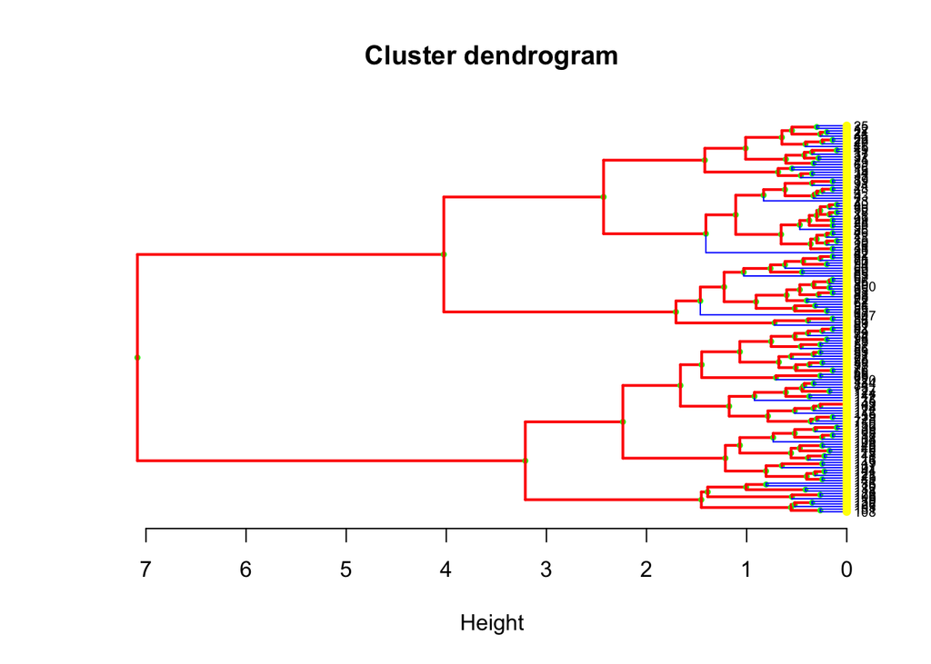

```r
# Convert hclust into a dendrogram and plot
hcd <- stats::as.dendrogram(hcluster)
# Define nodePar
nodePar <- list(lab.cex = 0.6, pch = c(20, 19),
                cex = 0.7, col = c("green","yellow"))
plot(hcd,  xlab = "Height", nodePar = nodePar, main = "Cluster dendrogram",
     edgePar = list(col = c("red","blue"), lwd = 2:1), horiz = TRUE)
```

## Method 2

```r
# Remove the categorical variable
iris2 <- iris[,-5]

#store as a separate dataframe
species <- iris[,5]

#convert to numeric and add a colour palette
species_col <- rev(rainbow_hcl(3))[as.numeric(species)]
```

### Plot a SPLOM (Scatterplot Matrix)

> just to have a look…

[figure not shown]

```r
# Plot a SPLOM:
pairs(iris2, col = species_col,
      lower.panel = NULL,
       cex.labels=2, pch=19, cex = 1.2)

# Add a legend
par(xpd = TRUE)
legend(x = 0.05, y = 0.4, cex = 3,
   legend = as.character(levels(species)),
    fill = unique(species_col))
```

```r
par(xpd = NA)
```

We can see that the Setosa species are distinctly different from Versicolor and Virginica (they have lower petal length and width). But Versicolor and Virginica cannot easily be separated based on measurements of their sepal and petal width/length.

> try method = “single”, method = “complete”, method = “average”
- Single works poorly
- Complete works OK (probably best)
- Average = all pairwise similarities & uses averages as distance

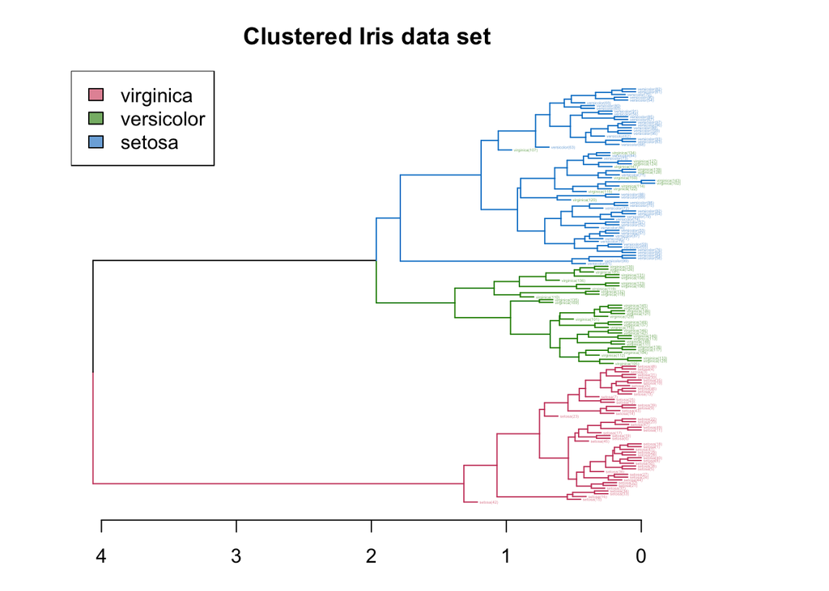

```r
d_iris <- stats::dist(iris2) # method="man" # is a bit better
hc_iris <- stats::hclust(d_iris, method = "average")
iris_species <- rev(levels(iris[,5]))

dend <- stats::as.dendrogram(hc_iris)
# order it the closest we can to the order of the observations:
dend <- rotate(dend, 1:150)

# Color the branches based on the clusters:
dend <- dendextend::color_branches(dend, k=3) #, groupLabels=iris_species)

# Manually match the labels, as much as possible, to the real classification of the flowers:
labels_colors(dend) <-
   rainbow_hcl(3)[sort_levels_values(
      as.numeric(iris[,5])[order.dendrogram(dend)]
   )]


# Add the flower type to the labels:
labels(dend) <- paste(as.character(iris[,5])[order.dendrogram(dend)],
                           "(",labels(dend),")",
                           sep = "")

# We hang the dendrogram a bit:
dend <- dendextend::hang.dendrogram(dend,hang_height=0.1)
# reduce the size of the labels:
# dend <- assign_values_to_leaves_nodePar(dend, 0.5, "lab.cex")
dend <- set(dend, "labels_cex", 0.2)
# And plot:
par(mar = c(3,3,3,7))
plot(dend,
     main = "Clustered Iris data set",
     horiz =  TRUE,  nodePar = list(cex = .007))
legend("topleft", legend = iris_species, fill = rainbow_hcl(3))
```

These visualizations easily demonstrates how the separation of the hierarchical clustering is very good with the “Setosa” species, but misses in labeling many “Versicolor” species as “Virginica”.

The hanging of the tree also helps to locate extreme observations. For example, we can see that observation “virginica (107)” is not very similar to the Versicolor species, but still, it is among them. Also, “Versicolor (71)” is located too much “within” the group of Virginica flowers.

> Measures of ‘goodness’?

### Elbow plot method

Similar to how we determined optimal clusters with k-means clustering, we can execute similar approaches for hierarchical clustering:

Elbow Method: To perform the elbow method we just need to change the second argument in fviz_nbclust to FUN = hcut.

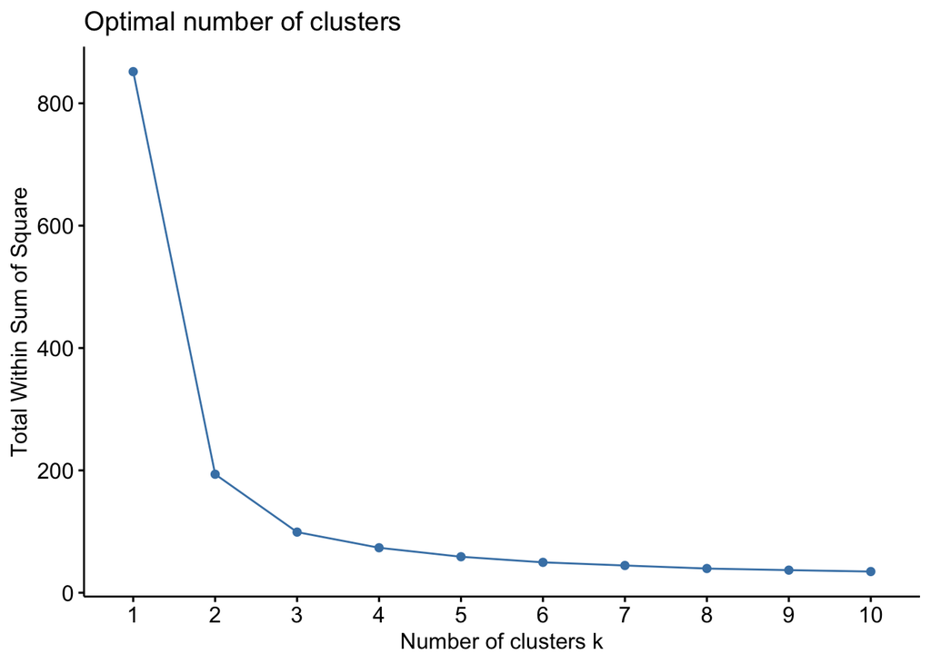

```r
factoextra::fviz_nbclust(iris, FUN = hcut, method = "wss")
```

### Examining different clustering methods (performance)

> test performance of “single” vs “complete” vs “average”

> XX added other linkage options to test

```r
# Select the methods of interest
hclust_methods <- c("single", "complete", "average",
                    "ward.D", "ward.D2", "centroid",
                    "mcquitty","median")
iris_dendlist <- dendextend::dendlist()
for(i in seq_along(hclust_methods)) {
   hc_iris <- stats::hclust(d_iris, method = hclust_methods[i])
   iris_dendlist <- dendextend::dendlist(iris_dendlist,
                                         as.dendrogram(hc_iris))
}
names(iris_dendlist) <- hclust_methods
iris_dendlist
```

```
## $single
## 'dendrogram' with 2 branches and 150 members total, at height 1.640122
##
## $complete
## 'dendrogram' with 2 branches and 150 members total, at height 7.085196
##
## $average
## 'dendrogram' with 2 branches and 150 members total, at height 4.062683
##
## $ward.D
## 'dendrogram' with 2 branches and 150 members total, at height 199.6205
##
## $ward.D2
## 'dendrogram' with 2 branches and 150 members total, at height 32.44761
##
## $centroid
## 'dendrogram' with 2 branches and 150 members total, at height 2.994307
##
## $mcquitty
## 'dendrogram' with 2 branches and 150 members total, at height 4.497283
##
## $median
## 'dendrogram' with 2 branches and 150 members total, at height 2.82744
##
## attr(,"class")
## [1] "dendlist"
```

```r
## Obtain coefficients and plot
iris_dendlist_cor <- dendextend::cor.dendlist(iris_dendlist)
iris_dendlist_cor
```

```
##             single  complete   average    ward.D   ward.D2  centroid  mcquitty
## single   1.0000000 0.5665529 0.9681156 0.9836838 0.9682507 0.9903934 0.9329029
## complete 0.5665529 1.0000000 0.6195121 0.5774013 0.6096286 0.5870062 0.6107473
## average  0.9681156 0.6195121 1.0000000 0.9841333 0.9895131 0.9801444 0.9828015
## ward.D   0.9836838 0.5774013 0.9841333 1.0000000 0.9911648 0.9809088 0.9641103
## ward.D2  0.9682507 0.6096286 0.9895131 0.9911648 1.0000000 0.9737886 0.9829977
## centroid 0.9903934 0.5870062 0.9801444 0.9809088 0.9737886 1.0000000 0.9499123
## mcquitty 0.9329029 0.6107473 0.9828015 0.9641103 0.9829977 0.9499123 1.0000000
## median   0.9444723 0.6889092 0.9449422 0.9451815 0.9445832 0.9403569 0.9203374
##             median
## single   0.9444723
## complete 0.6889092
## average  0.9449422
## ward.D   0.9451815
## ward.D2  0.9445832
## centroid 0.9403569
## mcquitty 0.9203374
## median   1.0000000
```

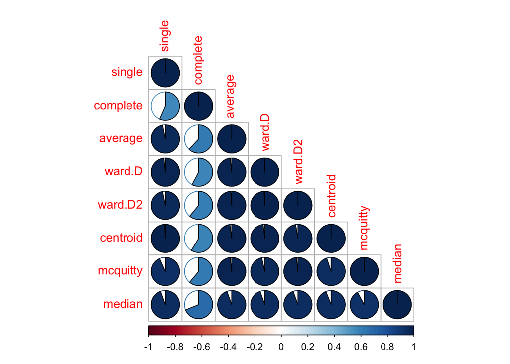

```r
corrplot::corrplot(iris_dendlist_cor, "pie", "lower")
```

> XX so they all correlate except ‘complete’ which suggests ‘complete’ is best (why?)

> XX Doesn’t this just show which produce the same results? YES

> Also try ward.D as a linkage method?

#### References:

1. https://cran.r-project.org/web/packages/dendextend/vignettes/Cluster_Analysis.html
2. https://cran.r-project.org/web/packages/dendextend/vignettes/Cluster_Analysis.html#iris---edgar-andersons-iris-data
3. https://www.kaggle.com/code/anna1231/hierarchical-clustering-of-iris-species/notebook